# Econometric model. Код подготовил Стельмашенко Григорий

Далее смотрим график остатки-прогнозы по каждой модели

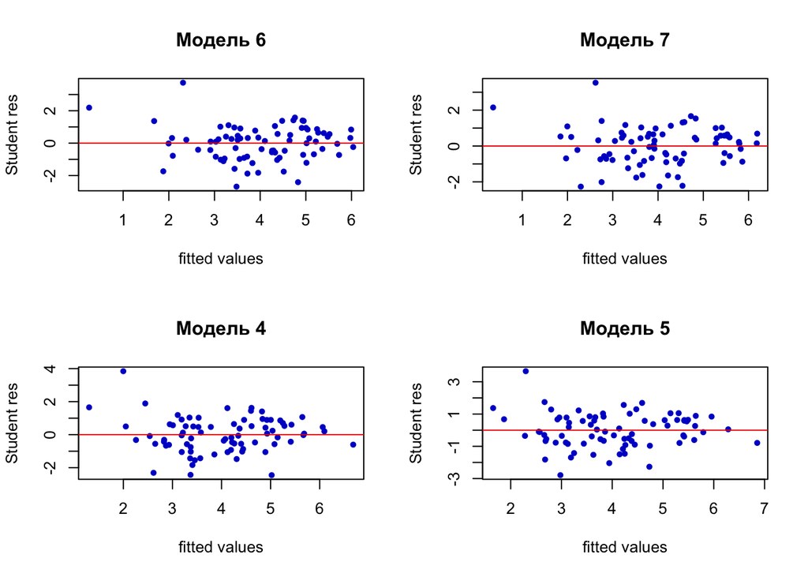

```r
#par(mfrow = c(2, 2))
#plot(mm9$fitted.values, mm9$residuals)
#abline(0,0, col = 'red2')
#plot(mm9.1$fitted.values, mm9.1$residuals)
#abline(0,0, col = 'red2')

par(mfrow = c(2, 2))
plot(mm7$fitted.values, studres(mm7), xlab = 'fitted values', ylab = 'Student res', main = 'Модель 6', pch = 20, col = 'blue3')
abline(0,0, col = 'red2')
plot(mm7.3$fitted.values, studres(mm7.3), xlab = 'fitted values', ylab = 'Student res', main = 'Модель 7', pch = 20, col = 'blue3')
abline(0,0, col = 'red2')
plot(mm9$fitted.values, studres(mm9), xlab = 'fitted values', ylab = 'Student res', main = 'Модель 4', pch = 20, col = 'blue3')
abline(0,0, col = 'red2')
plot(mm9.1$fitted.values, studres(mm9.1), xlab = 'fitted values', ylab = 'Student res', main = 'Модель 5', pch = 20, col = 'blue3')
abline(0,0, col = 'red2')
```

Смотрим нормальность остатков с помощью JB теста, гистограммы и qq plot. Ниже представлены p-value по JB тесту

```r
mm7JB = jarque.test(mm7$residuals)
mm7.3JB = jarque.test(mm7.3$residuals)
mm9JB = jarque.test(mm9$residuals)
mm9.1JB = jarque.test(mm9.1$residuals)
JBt = c(mm7JB$p.value, mm7.3JB$p.value, mm9JB$p.value,
                   mm9.1JB$p.value)
names(JBt)[1] = "mm7"
names(JBt)[2] = "mm7.3"
names(JBt)[3] = "mm9"
names(JBt)[4] = "mm9.1"
JBt
```

```
##       mm7     mm7.3       mm9     mm9.1
## 0.8983101 0.9987867 0.6562333 0.9197409
```

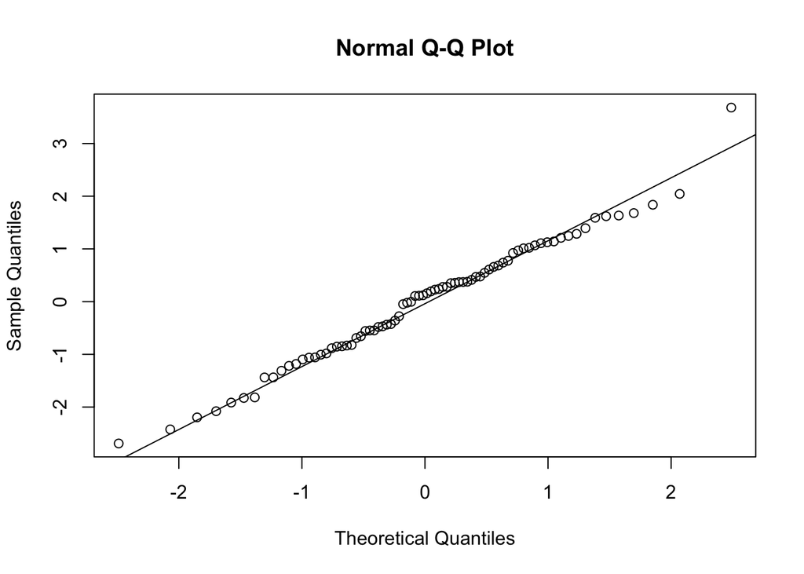

```r
par(mfrow = c(1, 1))
qqnorm(mm7$residuals)
qqline(mm7$residuals, distribution = qnorm) #идет вместе с
```

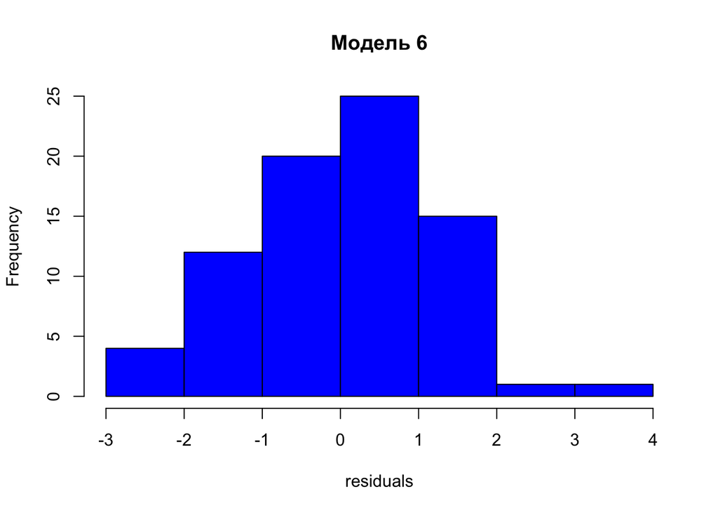

```r
#qqnorm, т е рисует на нем!!!
hist(mm7$residuals, col = 'blue', xlab = 'residuals', main = 'Модель 6')
```

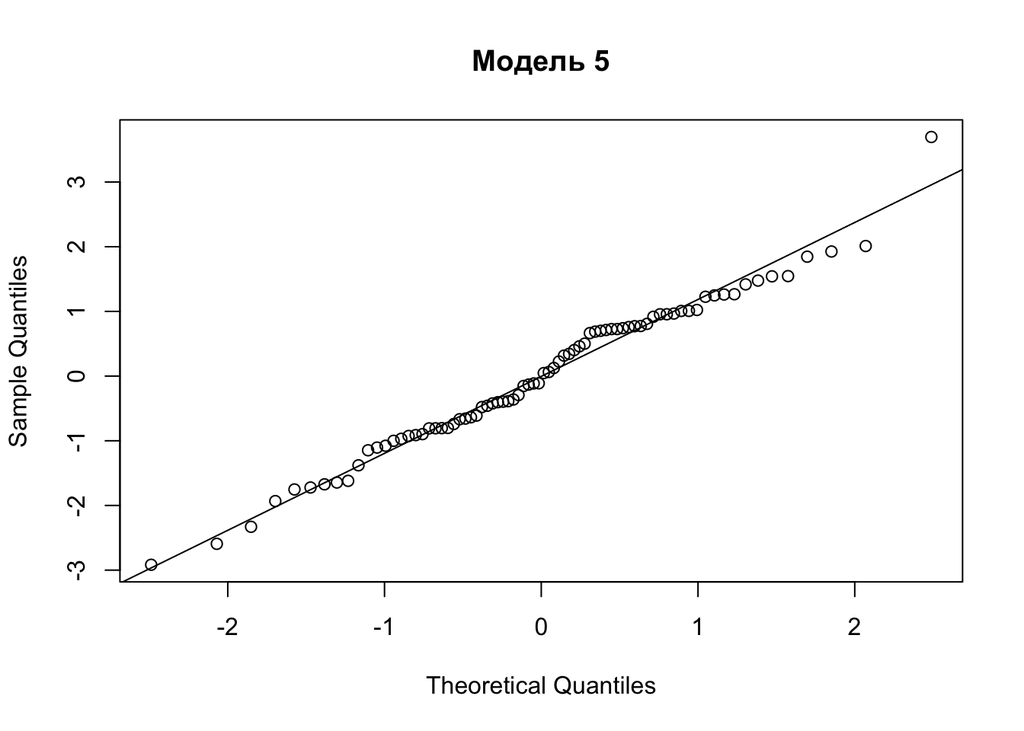

```r
qqnorm(mm9.1$residuals, main = 'Модель 5')
qqline(mm9.1$residuals, distribution = qnorm) #идет вместе с
```

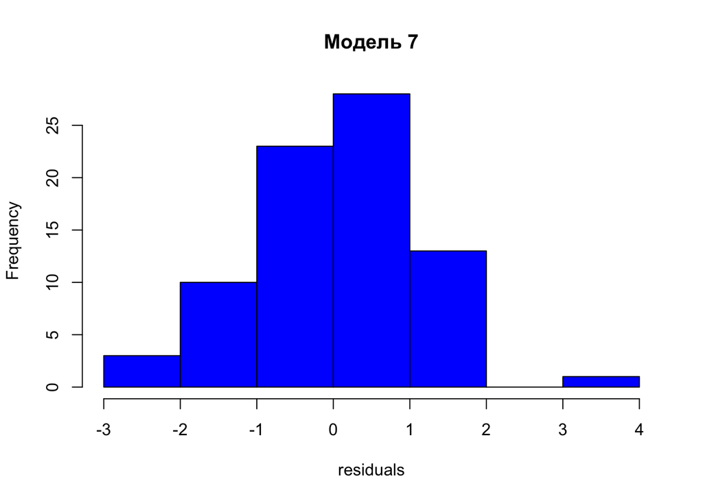

```r
#qqnorm, т е рисует на нем!!!
hist(mm7.3$residuals, col = 'blue', xlab = 'residuals', main = 'Модель 7')
```

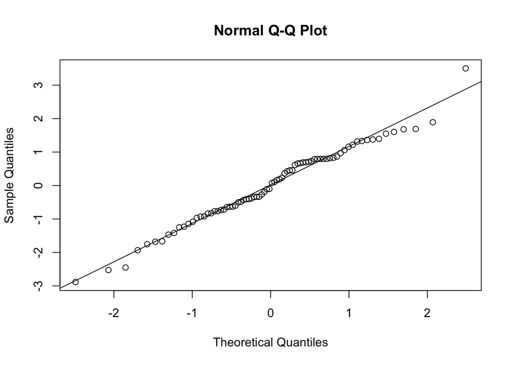

```r
qqnorm(mm7.2$residuals)
qqline(mm7.2$residuals, distribution = qnorm) #идет вместе с
```

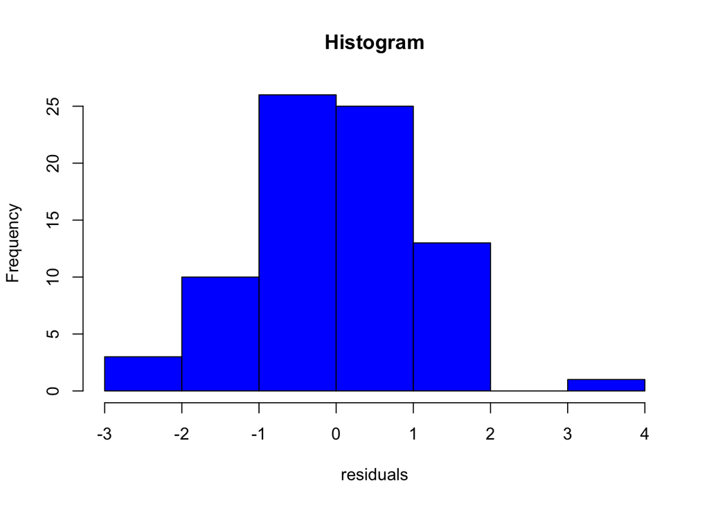

```r
#qqnorm, т е рисует на нем!!!
hist(mm7.2$residuals, col = 'blue', xlab = 'residuals', main = 'Histogram')
```

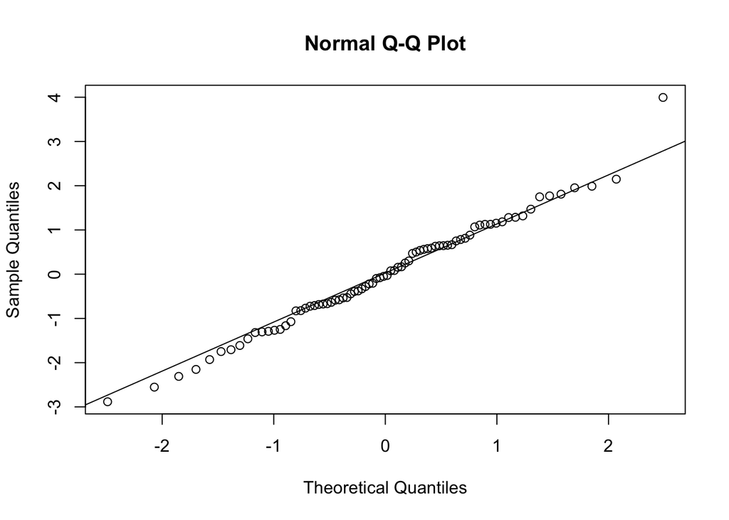

```r
qqnorm(mm9$residuals)
qqline(mm9$residuals, distribution = qnorm) #идет вместе с
```

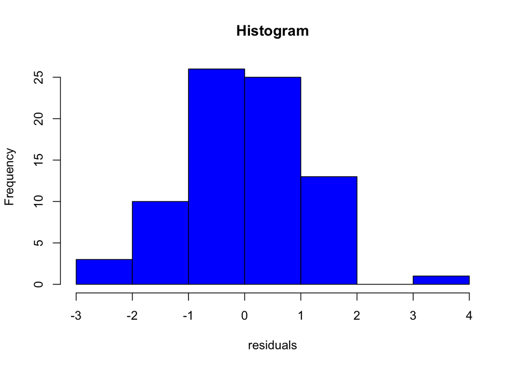

```r
#qqnorm, т е рисует на нем!!!
hist(mm7.2$residuals, col = 'blue', xlab = 'residuals', main = 'Histogram')
```

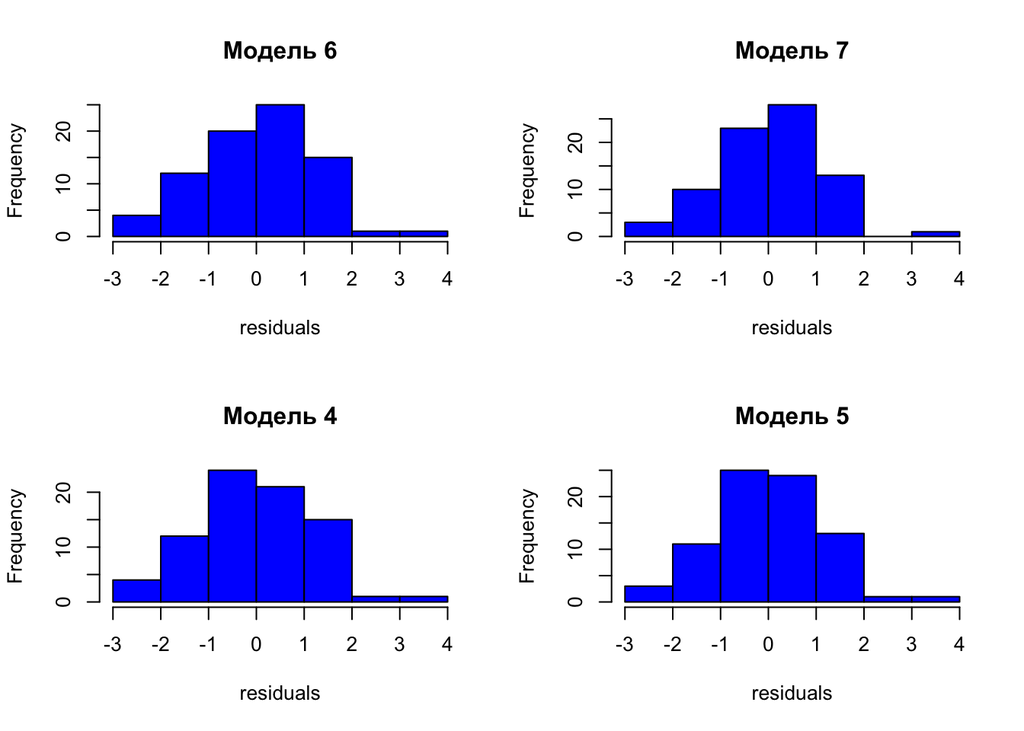

```r
par(mfrow = c(2, 2))
hist(mm7$residuals, col = 'blue', xlab = 'residuals', main = 'Модель 6')
hist(mm7.3$residuals, col = 'blue', xlab = 'residuals', main = 'Модель 7')
hist(mm9$residuals, col = 'blue', xlab = 'residuals', main = 'Модель 4')
hist(mm9.1$residuals, col = 'blue', xlab = 'residuals', main = 'Модель 5')
```

Далее смотрим гетероскедастичность

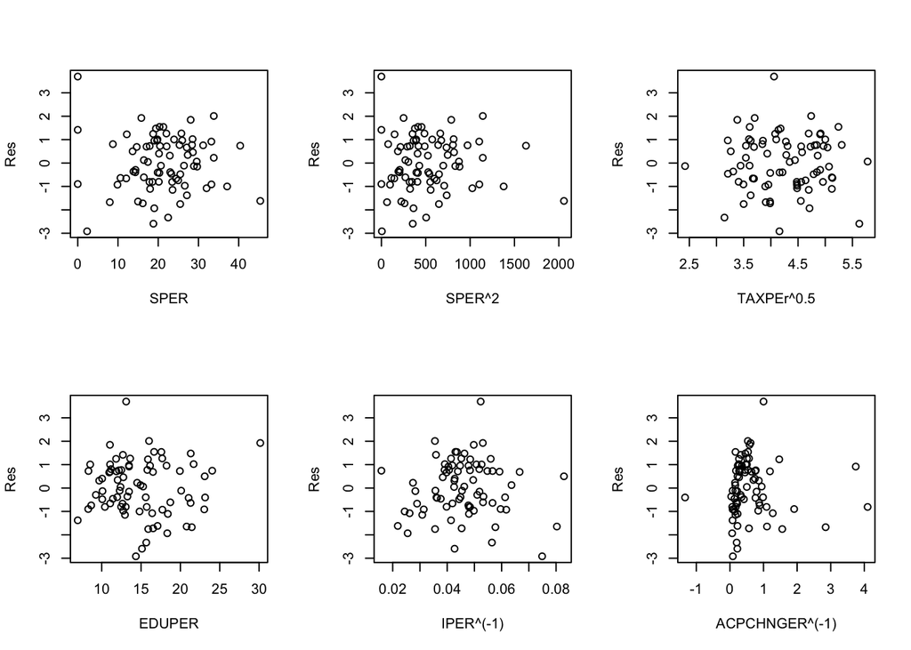

```r
#g1 = plot(na.omit(f$EDUPER), m8$residuals,)
#g1 = plot(mm2$model$SPER, mm2$residuals)
#g2 = plot(na.omit(mm7$model$`log(GDPPC/Deflator)`), mm7$residuals)
par(mfrow = c(2, 3))
g3 = plot(na.omit(mm9.1$model$SPER), mm9.1$residuals, xlab = 'SPER', ylab = 'Res')
g4 = plot(na.omit(mm9.1$model$`I(SPER^2)`), mm9.1$residuals, xlab = 'SPER^2', ylab = 'Res')
g5 = plot(na.omit(mm9.1$model$`I(sqrt(TAXPER))`), mm9.1$residuals, xlab = 'TAXPEr^0.5', ylab = 'Res')
#g6 = plot(na.omit(mm9.1$model$EDUPER), mm9$residuals)
g7 = plot(na.omit(mm9.1$model$EDUPER), mm9.1$residuals, xlab = 'EDUPER', ylab = 'Res')

#g8 = plot(na.omit(m1$model$), m1$residuals)
g9 = plot(na.omit(mm9.1$model$`I(IPER^(-1))`), mm9.1$residuals, xlab = 'IPER^(-1)', ylab = 'Res')
g5 = plot(na.omit(mm9.1$model$`I(ACPCHNGPER^(-1))`), mm9.1$residuals, xlab = 'ACPCHNGER^(-1)', ylab = 'Res')
```

```r
g3+g4+g5+g7+g9+g5 #library patchwork, работает только для ggplot2
```

```
## integer(0)
```

Реализуем тест Голдфельда Квандта. Здесь представлены не все данные

```r
gqtest(data = f, mm7, order.by = ~mm7$model$`I(IPER^(-1))`, fraction = 0.2)
```

```
##
##  Goldfeld-Quandt test
##
## data:  mm7
## GQ = 0.84835, df1 = 25, df2 = 24, p-value = 0.6575
## alternative hypothesis: variance increases from segment 1 to 2
```

```r
gqtest(data = f, mm9, order.by = ~mm9$model$`I(ACPCHNGPER^(-1))`, fraction = 0.2)
```

```
##
##  Goldfeld-Quandt test
##
## data:  mm9
## GQ = 2.1519, df1 = 25, df2 = 24, p-value = 0.03233
## alternative hypothesis: variance increases from segment 1 to 2
```

```r
gqtest(data = f, mm9, order.by = ~mm9$model$EDUPER, fraction = 0.2)
```

```
##
##  Goldfeld-Quandt test
##
## data:  mm9
## GQ = 2.4195, df1 = 25, df2 = 24, p-value = 0.01692
## alternative hypothesis: variance increases from segment 1 to 2
```

Далее смотрим RESET тест по каждой модели

```r
mm7R = resettest(mm7)
mm7.3R = resettest(mm7.3)
mm9R = resettest(mm9)
mm9.1R = resettest(mm9.1)
RT = c(mm7R$p.value, mm7.3R$p.value, mm9R$p.value,
                   mm9.1R$p.value)
names(RT)[1] = "mm7"
names(RT)[2] = "mm7.3"
names(RT)[3] = "mm9"
names(RT)[4] = "mm9.1"
RT
```

```
##         mm7       mm7.3         mm9       mm9.1
## 0.011547393 0.023103271 0.001436106 0.017302936
```

Теперь посмотрим на ковариационную матрицу каждой модели, дисперсии ошибок в форме Ньюи-Вэста

```r
HAC = vcovHAC(mm9.1)
C = vcov(mm9.1)
data.frame(HAC)
```

|  | X.Intercept. | SPER | I.SPER.2. | I.sqrt.TAXPER.. | EDUPER | I.IPER...1.. | I.ACPCHNGPER...1.. | SPER10 |
| --- | --- | --- | --- | --- | --- | --- | --- | --- |
| (Intercept) | 2.551627494 | -0.0983101996 | 1.373259e-03 | -1.315240e-01 | -1.402853e-02 | -10.89985767 | 2.506655e-02 | 0.2579829616 |
| SPER | -0.098310200 | 0.0092188137 | -1.666260e-04 | -5.631485e-04 | 1.211075e-04 | -0.15390919 | 4.468851e-03 | -0.0208862846 |
| I(SPER^2) | 0.001373259 | -0.0001666260 | 3.628892e-06 | 1.651788e-05 | -1.212362e-05 | 0.00973647 | -9.804352e-05 | 0.0001375075 |
| I(sqrt(TAXPER)) | -0.131524028 | -0.0005631485 | 1.651788e-05 | 5.083669e-02 | 2.191613e-04 | -1.35232152 | -1.080386e-02 | -0.0318356921 |
| EDUPER | -0.014028529 | 0.0001211075 | -1.212362e-05 | 2.191613e-04 | 1.232602e-03 | -0.07787228 | 1.049703e-03 | 0.0054519889 |
| I(IPER^(-1)) | -10.899857674 | -0.1539091914 | 9.736470e-03 | -1.352322e+00 | -7.787228e-02 | 348.61316045 | -1.154314e+00 | 1.4199127925 |
| I(ACPCHNGPER^(-1)) | 0.025066546 | 0.0044688506 | -9.804352e-05 | -1.080386e-02 | 1.049703e-03 | -1.15431404 | 3.875317e-02 | -0.0187248446 |
| SPER10 | 0.257982962 | -0.0208862846 | 1.375075e-04 | -3.183569e-02 | 5.451989e-03 | 1.41991279 | -1.872484e-02 | 0.2628985447 |

Анализ мультиколлинеарности

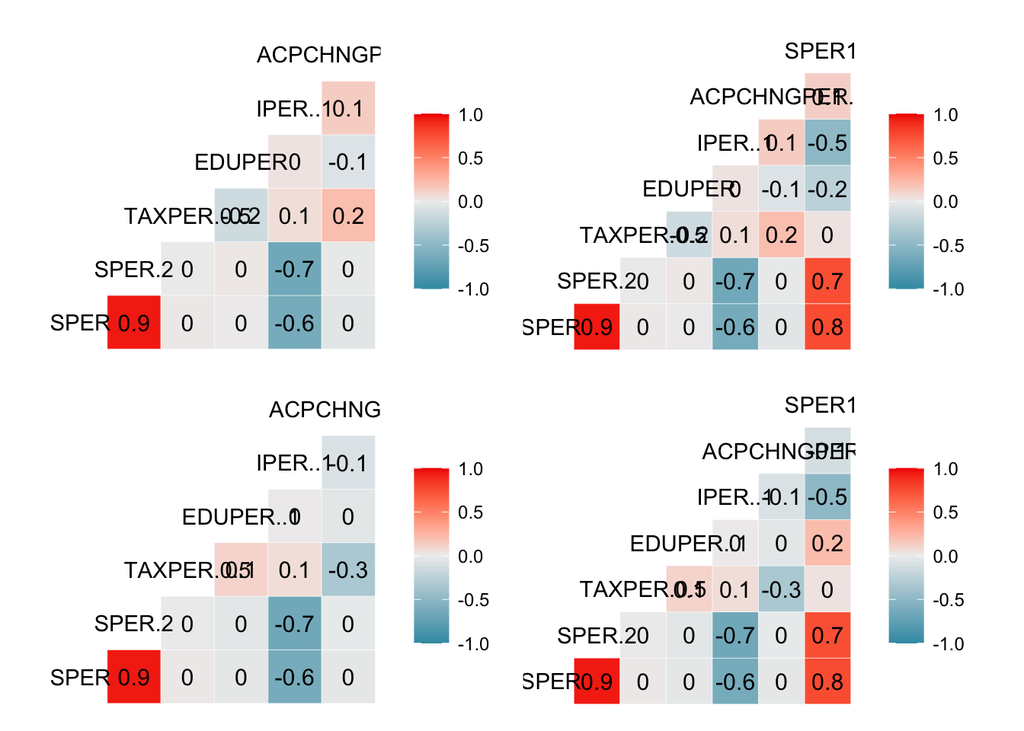

```r
cc1 = data.frame(mm9$model$SPER, mm9$model$`I(SPER^2)`, mm9$model$`I(sqrt(TAXPER))`,
                mm9$model$EDUPER, mm9$model$`I(IPER^(-1))`, mm9$model$`I(ACPCHNGPER^(-1))`)
colnames(cc1) = c('SPER', 'SPER^2', 'TAXPER^0.5', 'EDUPER', 'IPER^-1', 'ACPCHNGPER^-1')
c11 = ggcorr(cc1, label = T, digits = 6)

cc2 = data.frame(mm9.1$model$SPER, mm9.1$model$`I(SPER^2)`, mm9.1$model$`I(sqrt(TAXPER))`,
                mm9.1$model$EDUPER, mm9.1$model$`I(IPER^(-1))`, mm9.1$model$`I(ACPCHNGPER^(-1))`, mm9.1$model$SPER10)
colnames(cc2) = c('SPER', 'SPER^2', 'TAXPER^0.5', 'EDUPER', 'IPER^-1', 'ACPCHNGPER^-1', 'SPER10')
c12 = ggcorr(cc2, label = T, digits = 2, )



cc3 = data.frame(mm7$model$SPER, mm7$model$`I(SPER^2)`, mm7$model$`I(sqrt(TAXPER))`,
                mm7$model$`I(EDUPER^(-1))`, mm7$model$`I(IPER^(-1))`, mm7$model$ACPCHNGPER)
colnames(cc3) = c('SPER', 'SPER^2', 'TAXPER^0.5', 'EDUPER^-1', 'IPER^-1', 'ACPCHNGPER')
c13 = ggcorr(cc3, label = T, digits = 2)

cc4 = data.frame(mm7.3$model$SPER, mm7.3$model$`I(SPER^2)`, mm7.3$model$`I(sqrt(TAXPER))`,
                mm7.3$model$`I(EDUPER^(-1))`, mm7.3$model$`I(IPER^(-1))`, mm7.3$model$ACPCHNGPER, mm7.3$model$SPER10)
colnames(cc4) = c('SPER', 'SPER^2', 'TAXPER^0.5', 'EDUPER^-1', 'IPER^-1', 'ACPCHNGPER', 'SPER10')
c14 = ggcorr(cc4, label = T, digits = 2)

c11+c12+c13+c14
```

Коэффициент VIF

```r
model6 = vif(mm7)
model7 = vif(mm7.3)
model4 = vif(mm9)
model5 = vif(mm9.1)
#data.frame(v1, v2, v3, v4)
data.frame(model6, model4)
```

|  | model6 | model4 |
| --- | --- | --- |
| SPER | 9.699926 | 9.834521 |
| I(SPER^2) | 10.276941 | 10.511460 |
| I(sqrt(TAXPER)) | 1.140214 | 1.075761 |
| I(EDUPER^(-1)) | 1.014052 | 1.032988 |
| I(IPER^(-1)) | 1.786674 | 1.822757 |
| ACPCHNGPER | 1.138867 | 1.093375 |

```r
data.frame(model7, model5)
```

|  | model7 | model5 |
| --- | --- | --- |
| SPER | 10.385349 | 10.713937 |
| I(SPER^2) | 10.514690 | 10.681107 |
| I(sqrt(TAXPER)) | 1.142032 | 1.079781 |
| I(EDUPER^(-1)) | 1.171657 | 1.218236 |
| I(IPER^(-1)) | 1.786769 | 1.823053 |
| ACPCHNGPER | 1.166395 | 1.154770 |
| SPER10 | 2.864837 | 3.027884 |

Анализ числа обусловленности

```r
X1 = model.matrix(data = f, ~SPER+I(SPER**2)+I(sqrt(TAXPER))+EDUPER+
            I(IPER**(-1))+I(ACPCHNGPER**(-1)))
XX1 = t(X1) %*% X1
eigen1 = eigen(XX1)
eigen1$values
```

```
## [1] 3.230498e+07 9.782482e+03 9.010644e+02 9.213332e+01 3.673800e+01
## [6] 1.013589e+00 6.192416e-03
```

```r
CI1 = sqrt(max(eigen1$values) / (min(eigen1$values)))
CI1
```

```
## [1] 72227.85
```

```r
X3 = model.matrix(data = f, ~SPER+I(SPER**2)+I(sqrt(TAXPER))+EDUPER+
            I(IPER**(-1))+I(ACPCHNGPER**(-1))+SPER10)
XX3 = t(X3) %*% X3
eigen3 = eigen(XX3)
eigen3$values
```

```
## [1] 3.230501e+07 9.782782e+03 9.026316e+02 9.218034e+01 3.712419e+01
## [6] 6.359584e+00 1.010942e+00 6.191380e-03
```

```r
CI3 = sqrt(max(eigen3$values) / (min(eigen3$values)))
CI3
```

```
## [1] 72233.92
```

```r
X2 = model.matrix(data = f,~1+SPER+I(SPER**2)+I(sqrt(TAXPER))+I(EDUPER**(-1))+I(IPER**(-1))+
                   ACPCHNGPER)
XX2 = t(X2) %*% X2
eigen2 = eigen(XX2)
eigen2$values
```

```
## [1] 3.229410e+07 4.012360e+03 1.269448e+03 1.063604e+02 1.147893e+00
## [6] 3.482473e-02 6.311028e-03
```

```r
CI2 = sqrt(max(eigen2$values) / (min(eigen2$values)))
CI2
```

```
## [1] 71533.84
```

```r
X4 = model.matrix(data = f,~1+SPER+I(SPER**2)+I(sqrt(TAXPER))+I(EDUPER**(-1))+I(IPER**(-1))+
                   ACPCHNGPER+SPER10)
XX4 = t(X4) %*% X4
eigen4 = eigen(XX4)
eigen4$values
```

```
## [1] 3.229413e+07 4.012376e+03 1.269797e+03 1.067375e+02 7.932321e+00
## [6] 1.132859e+00 3.008501e-02 6.310961e-03
```

```r
CI4 = sqrt(max(eigen4$values) / (min(eigen4$values)))
CI4
```

```
## [1] 71534.25
```

Анализ моделей по BIC и AIC

```r
data.frame(BIC(mm7), BIC(mm7.3), BIC(mm9), BIC(mm9.1))
```

| BIC.mm7. | BIC.mm7.3. | BIC.mm9. | BIC.mm9.1. |
| --- | --- | --- | --- |
| 279.1966 | 277.3579 | 287.2522 | 286.1888 |

```r
data.frame(AIC(mm7), AIC(mm7.3), AIC(mm9), AIC(mm9.1))
```

| AIC.mm7. | AIC.mm7.3. | AIC.mm9. | AIC.mm9.1. |
| --- | --- | --- | --- |
| 260.343 | 256.1476 | 268.3985 | 264.9784 |

Анализ зависимости ВВП на душу (PPC) от доли налогов в ВВП

```r
f$PPC = (f$GDPPC / f$Deflator)
describe(f$PPC)
```

|  | vars | n | mean | sd | median | trimmed | mad | min | max | range | skew | kurtosis | se |
| --- | --- | --- | --- | --- | --- | --- | --- | --- | --- | --- | --- | --- | --- |
| X1 | 1 | 95 | 151.7447 | 217.0776 | 42.29253 | 107.6961 | 54.31183 | 1.063853 | 1057.869 | 1056.805 | 1.812428 | 2.895077 | 22.27169 |

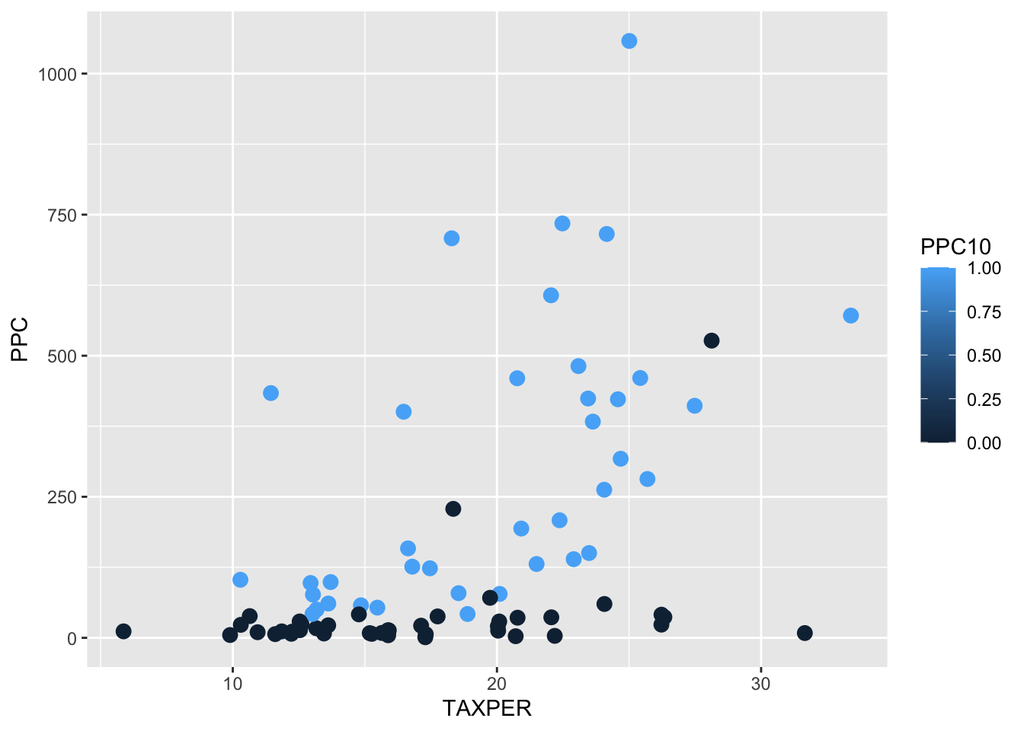

```r
for (i in 1:78){
  if (f$PPC[i] > 42.29){
    f$PPC10[i] = 1
  }
  else {
    f$PPC10[i] = 0
    }
}
ggplot(f[which(f$TAXPER > 0),], aes(TAXPER, PPC, col = PPC10))+geom_point(size = 3)
```

```r
d1 = ggplot(f, aes(IPER, log(GDPPC / Deflator), col = SPER10))+
  geom_point()
```